# Homework 1

Linguistic Data: Quantitative Analysis and Visualisation. Linguistic theory group.

Deadline: 9 February, 23:59:59

The solutions should be submitted via GitHub.

## Part 1. A preliminary training

*Do not use R (RStudio) to solve problems in Part 1.*

### Problem 1

Look at the following histogram and answer the questions.

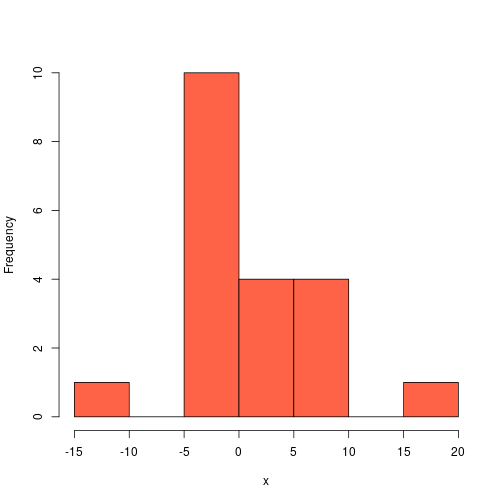

1. What is the proportion of values in the sample that exceed $5$? Explain your answer.

Посмотрим на значения в интервалах `[5:10]` и дальше: их 5 штук. Остальных значений 15. Всего 20. Значит, 5/20 = четверть.

Ответ: четверть.

2. Indicate the interval where the median of this sample can lie. Explain your answer.

Вычтем из двадцати десять, получим десять. Значит, медиана будет примерно где-то на десятом значении, то есть в интервале `[-5:10]`.

Ответ: `[-5:10]`

3. How the histogram will change if we add an element $7$ to the sample? Explain your answer.

Интервал `[5:10]` вырастет на один пункт.

### Problem 2

1. Look at the histograms of two samples. They illustrate the distribution of normalized average reaction time to frequent words (in ms) in two groups of people.

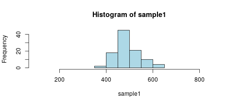

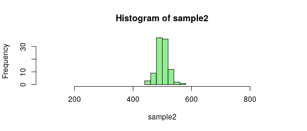

Which of the samples has a larger variance? Explain your answer.

2. Look at the histograms of two samples.

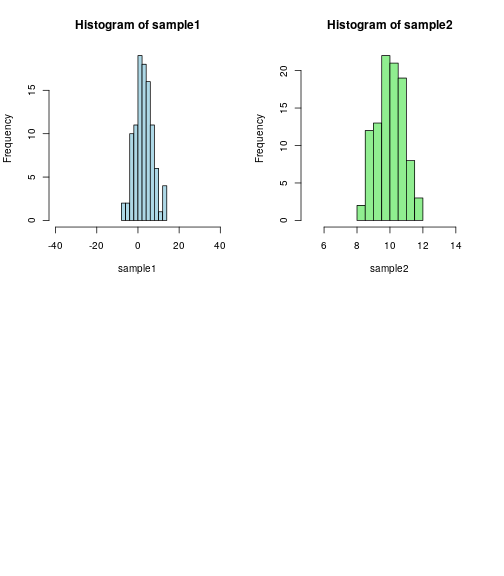

Which of the samples has a larger variance? Explain your answer.

## Part 2

*Do not use R (RStudio) to solve problems in Part 2. Answers for problem 3 will be evaluated. Please paste YES or NO into (empty) code blocks and explain you answer below the block.*

### Problem 3

Below is the histogram of the number of mistakes students made while writing an examination essay in English. Look at the histogram and answer the questions.

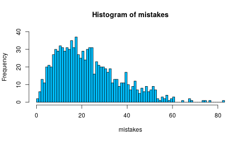

#### 3.1

Is it true that $50$% students made more than $35$ mistakes?

```
нет
```

Explain your answer below:

Кажется, что большинство наоборот сделали меньше 35-ти ошибок.

#### 3.2

Is it true that most students made no more than $10$ mistakes?

```
нет
```

Explain your answer below:

Пики идут после 10-ти.

#### 3.3

Which of the following values is closer to the median of `mistakes`: $10$, $20$, $30$, $40$?

```
20
```

Explain your answer below:

Я бы сказал, что между 20 и 30.

### Problem 4. Exact binomial test

In a certain language there are two forms of a word “go”: normal and dialectical. Whe know that if we select random person from the Country, this person will use normal form with probability 2/3 and dialectical form with probability 1/3. (One person uses only one form all the time.) Researcher suggests that the percentage of people who use dialectical form in a particular City is higher than in the Country. To prove this point, she proceed with the following experiment. Random person from the City is selected and his/her usage of word “go” is recorded. This is repeated $n$ times (the same person theoretically can be chosen more than one time, but the City is large comparatively to $n$, so it rarely occurs in practice).

The results are as following: 20 informants where selected ($n=20$), 17 of them use dialectical form.

Is it enough to say that the percentage of people who use dialectical form in the City is higher than in the Country.

#### 4.1 Hypothesis

State the null hypothesis and alternative.

$H_0$: распространённость диалектной формы в Городе не отличается от распространённости в стране

$H_1$: отличается

#### 4.2 Find p-value

Recall that p-value is a probability to get the data that we obtained or “more extreme” (more convincing to reject null hypothesis in favor of alternative) provided that null hypothesis holds. Find p-value for your data.

**Hint.** There is a function `dbinom(k, n, p)` in R that calculates probability to get `k` heads if you toss a coin `n` times and probability to obtain a head in one tossing is `p`. You can use this function here. Так как R в этой части использовать нельзя, используем Python

[output not shown]

#### 4.3 Conclusion

Will you reject null hypothesis? Use significance level of 5%.

Да, p-value меньше пяти сотых.

#### 4.4 Answer

Can we claim that we have enough evidence to say that the percentage of people who use dialectical form in the City is higher than in the Country?

Да (только информантов мало, к тому же хотелось бы видеть выборку для страны в целом).

## Part 3

*Use R (RStudio) to solve problems in Part 3. Your answers will be evaluated. Please paste R code into R code blocks and explain you answer below the block, if needed.*

### Problem 5

Here is a sample of respondents’ age:

$44$, $50$, $42$, $64$, $66$, $42$, $72$, $56$, $72$, $54$, $46$, $48$, $48$, $52$, $50$, $66$, $84$.

#### 5.1

Arrange them in a vector and call it `age`.

```r
age = c(44, 50, 42, 64, 66, 42, 72, 56, 72, 54, 46, 48, 48, 52, 50, 66, 84)
```

#### 5.2

Examine the type of `age` variable (numeric, character, etc).

```
> class(age)
[1] "numeric"
```

#### 5.3

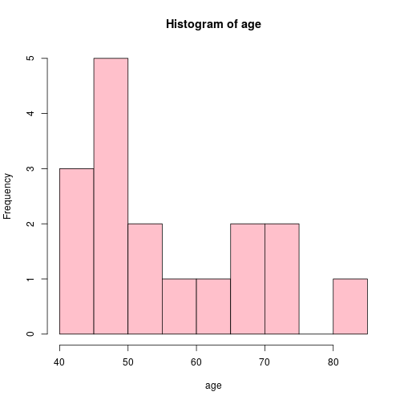

```r
hist(age, col="pink")
```

### Problem 6

Here is a series of words:  
*pie, bar, bar, pie, pie, bar, bar, chart*.

#### 6.1

Arrange elements above in a vector and call it `words`

```r
words = c('pie', 'bar', 'bar', 'pie', 'pie', 'bar', 'bar', 'chart')
```

#### 6.2

Calculate the relative frequences of values in `words` measured in percent.

```r
table(words) * 100 / sum(table(words))
```

```
## words
##   bar chart   pie
##  50.0  12.5  37.5
```

## Supplementary reading

Use of exact binomial test in linguistic research:

- Gries, Stefan Th. “Phonological similarity in multi-word units.” Cognitive Linguistics 22.3 (2011): 491-510. [Link](http://citeseerx.ist.psu.edu/viewdoc/download?doi=10.1.1.186.7412&rep=rep1&type=pdf)  
  Stefan Gries proves that alliteration is observed in multi-word expressions more often than in general.
- Harald Bayen (2008: 51-52) evaluates the probability of observing exactly one occurrence of the word *hare* in the corpus sample of 1 mln words given its estimated frequency of 8.23 words per million according to the SELEX frequency database.

On measures of central tendency:

- Levshina 2015, Chapter 3 (p. 48); Gries 2009, Chapter 1.3 (p. 116).